# **Report on R usage & training needs**

The most popular nicknames.

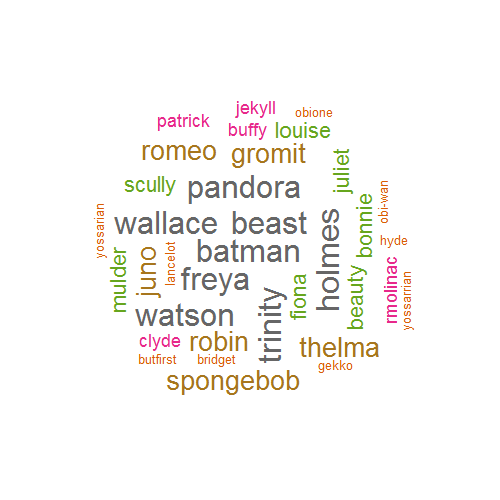

We surveyed MarSci teams on their R usage. It turns out that most of us uses R on a daily basis.

[interactive chart not shown]

## **R users**

### **Experience with R**

We asked R users how long have they been working in R.  
*(yes, we forgot about possibility of working in R between 1-2 years…)*

[interactive chart not shown]

### **Development direction**

We also asked in which direction would you like to go- R skills improvement or Shiny training. It turns out that most of you would rather focus on R skills. However, the content of the course came up in open answers, some of you would hesitate between those two depending on the advancement level of the training (more advanced being preferred).

[interactive chart not shown]

#### **Development directions by experience**

[interactive chart not shown]

### **Usage of packages**

We asked which packages do you use and which do you want to learn. Many of you declared both usage and willigness to learn certain packages. Below is the list of packages by usage and need to learn declarations.

- ‘I use it’ declaration means ‘I use it’ or ‘I use it’ **and** ‘I want to learn it’ was picked
- ‘I want to learn it’ declaration means answear contained willigness to learn declaration alone or combined with ‘I do not use it’ or ‘I use it’

[interactive chart not shown]

#### **Usage of packages by experience**

[interactive chart not shown]

#### **Your packages recommendations**

Which other packages you recommended in open question ?

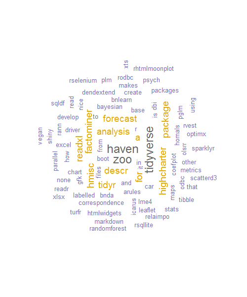

## **R non users**

Among those who don’t use R, we asked questions whether they would like to learn it and other software they use.

[interactive chart not shown]

So what do we use assuming we do not work in R ?

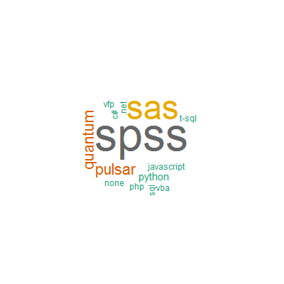